# Predective Analysis to Classify the Execution of Weight Lifting Exercise

Aman Bhagat

6/8/2020

## Overview

Using devices such as Jawbone Up, Nike FuelBand, and Fitbit it is now possible to collect a large amount of data about personal activity relatively inexpensively. These type of devices are part of the quantified self movement – a group of enthusiasts who take measurements about themselves regularly to improve their health, to find patterns in their behavior, or because they are tech geeks. One thing that people regularly do is quantify how much of a particular activity they do, but they rarely quantify how well they do it. In this project, your goal will be to use data from accelerometers on the belt, forearm, arm, and dumbell of 6 participants. They were asked to perform barbell lifts correctly and incorrectly in 5 different ways. More information is available from the website here: http://groupware.les.inf.puc-rio.br/har (see the section on the Weight Lifting Exercise Dataset).

The goal of your project is to predict the manner in which they did the exercise. This is the “classe” variable in the training set. You may use any of the other variables to predict with. You should create a report describing how you built your model, how you used cross validation, what you think the expected out of sample error is, and why you made the choices you did. You will also use your prediction model to predict 20 different test cases.

## Data Defination

```r
pml.testing <- read.csv("pml-testing.csv")
pml.training <- read.csv("pml-training.csv")
```

Lets look at the dimensions of our training data.

```r
dim(pml.training)
```

```
## [1] 19622   160
```

As we can see there are 19622 observations of 160 variables are present, we can fairly say that’s its not possible to show the summary of the dataset in this report. As we have abundant data to train the model so we would create a partition from data set for the cross validation.

```r
library(caret)
inTrain <- createDataPartition(y = pml.training$classe , p = 0.70, list = FALSE )
pml.train <- pml.training[inTrain,]
pml.crossValidate <- pml.training[-inTrain,]
dim(pml.train)
```

```
## [1] 13737   160
```

```r
dim(pml.crossValidate)
```

```
## [1] 5885  160
```

Now we have divided our data set into 7:3 ratio for the cross validation.

## Data Preprocessing

```r
library(caret)
nzv <- nearZeroVar(pml.train, saveMetrics = TRUE)
pml.train <- pml.train[,nzv$nzv == FALSE]
pml.testing <- pml.testing[,nzv$nzv == FALSE]
pml.crossValidate <- pml.crossValidate[, nzv$nzv == FALSE]
```

Now we have removed the variables which have variablity near zero. Now we check for the NA’s in our variable which can temper our results.

```r
columnsum <- colSums(is.na(pml.train))
columnsum[columnsum>1000]
```

```
##            max_roll_belt           max_picth_belt            min_roll_belt
##                    13461                    13461                    13461
##           min_pitch_belt      amplitude_roll_belt     amplitude_pitch_belt
##                    13461                    13461                    13461
##     var_total_accel_belt            avg_roll_belt         stddev_roll_belt
##                    13461                    13461                    13461
##            var_roll_belt           avg_pitch_belt        stddev_pitch_belt
##                    13461                    13461                    13461
##           var_pitch_belt             avg_yaw_belt          stddev_yaw_belt
##                    13461                    13461                    13461
##             var_yaw_belt            var_accel_arm            max_picth_arm
##                    13461                    13461                    13461
##              max_yaw_arm             min_roll_arm            min_pitch_arm
##                    13461                    13461                    13461
##              min_yaw_arm        amplitude_yaw_arm        max_roll_dumbbell
##                    13461                    13461                    13461
##       max_picth_dumbbell        min_roll_dumbbell       min_pitch_dumbbell
##                    13461                    13461                    13461
##  amplitude_roll_dumbbell amplitude_pitch_dumbbell       var_accel_dumbbell
##                    13461                    13461                    13461
##        avg_roll_dumbbell     stddev_roll_dumbbell        var_roll_dumbbell
##                    13461                    13461                    13461
##       avg_pitch_dumbbell    stddev_pitch_dumbbell       var_pitch_dumbbell
##                    13461                    13461                    13461
##         avg_yaw_dumbbell      stddev_yaw_dumbbell         var_yaw_dumbbell
##                    13461                    13461                    13461
##         max_roll_forearm        max_picth_forearm         min_roll_forearm
##                    13461                    13461                    13461
##        min_pitch_forearm   amplitude_roll_forearm  amplitude_pitch_forearm
##                    13461                    13461                    13461
##        var_accel_forearm         avg_roll_forearm
##                    13461                    13461
```

Here we can see that there are alot of variables which has more than 1000 NAs and almost 97% of the values in the variable are NA’s. Therefore it would be a good idea to remove those variables from out dataset.

```r
train.withoutNa <- pml.train[ , colSums(is.na(pml.train))/13737 <= 0.90]
sum(is.na(train.withoutNa))
```

```
## [1] 0
```

```r
testing.withoutNA <- pml.testing[,colSums(is.na(pml.train))/13737 <= 0.90]
crossvalidate.withoutNA <- pml.crossValidate[,colSums(is.na(pml.train))/13737 <= 0.90]
```

Now, we have removed those predictors from the dataset that has NAs over 90 percent. We did the same for the testing data and crossvalidate data.

```r
dim(train.withoutNa)
```

```
## [1] 13737    59
```

We can see that the number of variables has been reduced to 59.

```r
#Removing Identification only variables
train.withoutNa <- train.withoutNa[,-(1:5)]
testing.withoutNA <- testing.withoutNA[,-(1:5)]
crossvalidate.withoutNA <- crossvalidate.withoutNA[,-(1:5)]
```

## Correlation Analysis

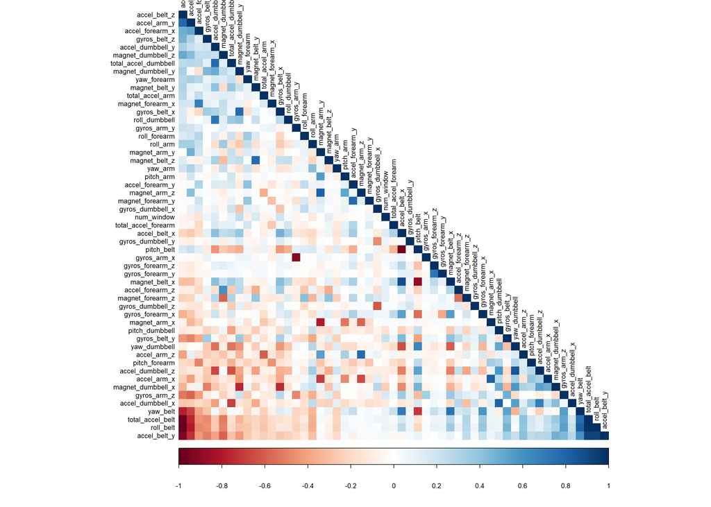

```r
library(corrplot)
corr <- cor(train.withoutNa[,-54])
corrplot(corr, order = "FPC", method = "color", type = "lower",tl.cex = 0.8, tl.col = rgb(0, 0, 0))
```

From the above Analysis we can infer that the variables which are highly correlated are shaded as dark color and which is very low in numbers. Therefore we can say that there are relatively less number of correlated variables in our dataset. Therefore we would not do Principal component Analysis in this assignment.

## Model Selection

We will now try to choose best model for the current training data.

### Model1: Random Forest

Initially we will train our model using Random Forest.

```r
fit.rf <- train(classe ~ ., method  = "rf" , data = train.withoutNa)
predict.rf <- predict(fit.rf, crossvalidate.withoutNA)
c1 <- confusionMatrix(predict.rf, crossvalidate.withoutNA$classe)
c1$overall["Accuracy"]
```

```
##  Accuracy
## 0.9984707
```

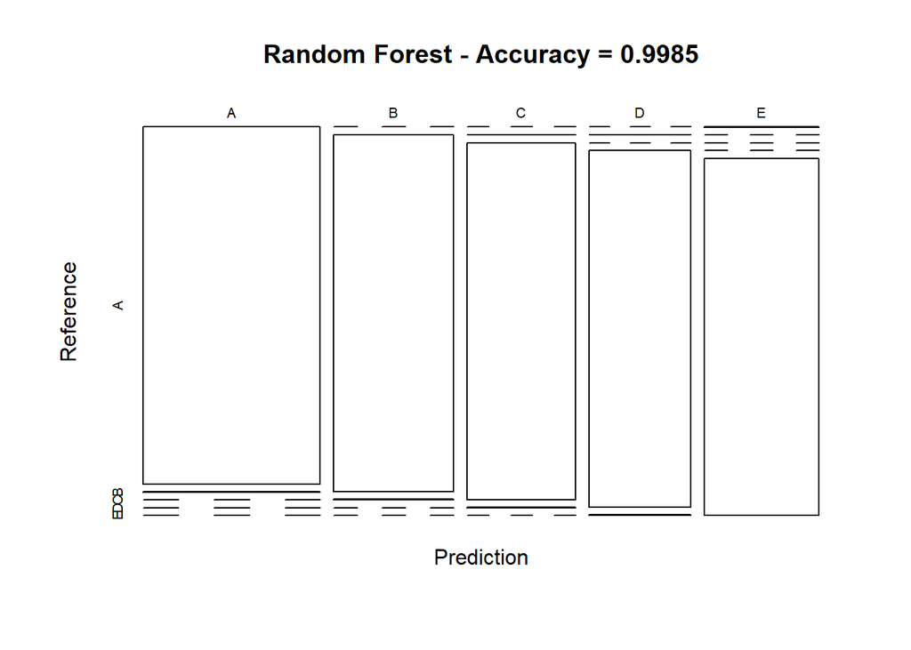

```r
plot(c1$table, col = c1$byClass, main = paste("Random Forest - Accuracy =",
                  round(c1$overall['Accuracy'], 4)))
```

Now we trained our model using random forest and we cross validate the data that we kept for crossvalidation. From the coross validation, the accuracy that we are getting by training our model with Randforest is arround 99 percentage which is highly accurate but the time taken by the model to train is high.

### Model2: Stochastic Gradient Boosting

```r
fit.gbm <- train(classe ~ ., method  = "gbm" , data = train.withoutNa, verbose = FALSE)
predict.gbm <- predict(fit.gbm, crossvalidate.withoutNA)
c2 <- confusionMatrix(predict.gbm, crossvalidate.withoutNA$classe)
c2$overall["Accuracy"]
```

```
##  Accuracy
## 0.9858963
```

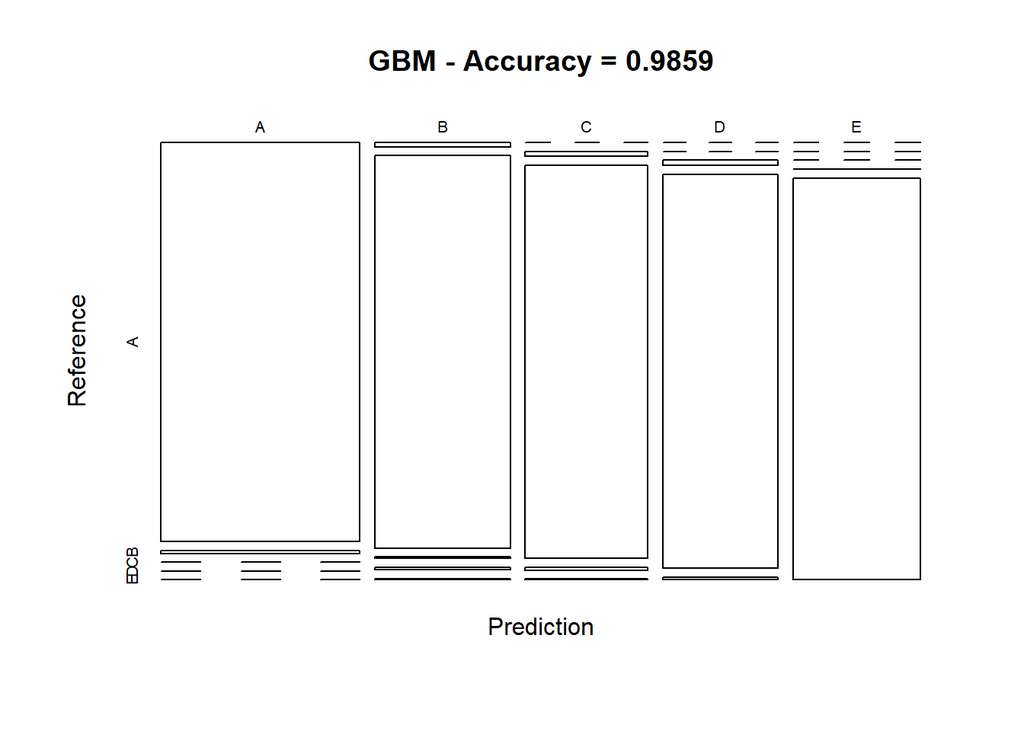

```r
plot(c2$table, col = c2$byClass, main = paste("GBM - Accuracy =",
                  round(c2$overall['Accuracy'], 4)))
```

Now, we have applied GBM model to train our data and cross validated the data using cross validation data set. We observed that it is also taking a lot of time to train the dataset. And the accuracy is comparitively less than the random forest model. Therefore we will reject this model and proceed further.

### Model3: Support Vector Machine

```r
library(e1071)
fit.svm <- svm(classe ~ ., method  = "svm" , data = train.withoutNa, verbose = FALSE)
predict.svm <- predict(fit.svm, crossvalidate.withoutNA)
c3 <- confusionMatrix(predict.svm, crossvalidate.withoutNA$classe)
c3$overall["Accuracy"]
```

```
##  Accuracy
## 0.9559898
```

[figure not shown]

```r
plot(c2$table, col = c2$byClass, main = paste("SVM - Accuracy =",
                  round(c3$overall['Accuracy'], 4)))
```

Now we have trained our data using SVM model and cross validated to get the accuracy. We observed that using SVM model which uses radial kernel takes relatively less time than the other two models but out of sample error is higher than the other two models.

## Results

```r
data.frame(RandomForest =  c1$overall["Accuracy"],
GBM = c2$overall["Accuracy"],SVM = c3$overall["Accuracy"])
```

```
##          RandomForest       GBM       SVM
## Accuracy    0.9984707 0.9858963 0.9559898
```

From the above results we can infer that Random Forest and GBM models takes time to train the data set whereas the SVM model takes much lesser time to train the data set. But the Accuracy of other two is comparatively high. Therefore there is a time and accuracy tradeoff. Here we will choose Random Forest model to classify from the given test dataset because the time taken to train the data is not that high on which we can reject this model.

```r
predict.svm.test <- predict(fit.rf, testing.withoutNA)
predict.svm.test
```

```
##  [1] B A B A A E D B A A B C B A E E A B B B
## Levels: A B C D E
```

Above are the results for the test data by applying Random Forest Model.